# Task 1 - Palmetto binary logistic regression (individual)

Pol Carbó Mestre

February 7, 2022

```r
# Attach packages.
library(tidyverse)
library(here)
library(ggtext)
library(equatiomatic)
library(GGally)
library(broom)
library(jtools)
library(caret)
library(AICcmodavg)
library(kableExtra)
library(ggbeeswarm)
library(patchwork)
library(janitor)
library(GGally)
```

```r
palmetto <- read_csv(here("data","palmetto.csv"))
palmetto$species <- as.factor(palmetto$species)
levels(palmetto$species) <- c("Serenoa repens","Sabal etonia")
```

# Overview

This task will explore binary logistic regressions to classify two species of Florida palmetto, *Serenoa repens* and *Sabal etonia*. The dataset used contains survival and growth data across multiple years, habitats, and experimental treatments. However, we will focus on the growth parameters to test the feasibility of using variables plant height (`height`), canopy length (`length`), canopy width (`width`), and the number of green leaves (`green_lvs`) to discriminate between species.

**Data source:** Abrahamson, W.G. 2019. Survival, growth and biomass estimates of two dominant palmetto species of south-central Florida from 1981 - 2017, ongoing at 5-year intervals ver 1. Environmental Data Initiative. https://doi.org/10.6073/pasta/f2f96ec76fbbd4b9db431c79a770c4d5

# Data visualization

For a first evaluation, we can create a scatterplot matrix to assess the relationships between the variables of interest by species.

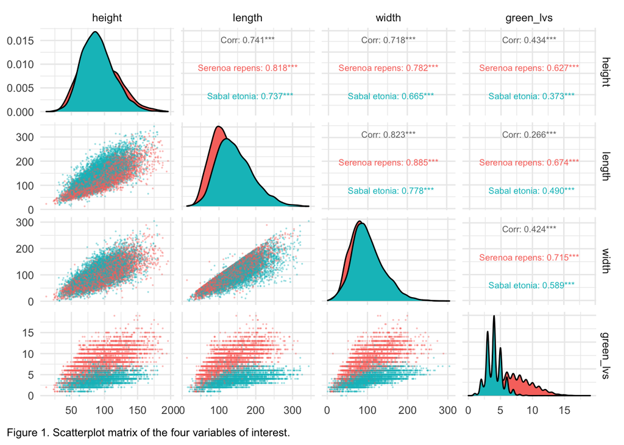

```r
ggpairs(palmetto, columns = 8:11,
        ggplot2::aes(color = species),
        lower = list(continuous = wrap("points", alpha = 0.3,size=0.1)),
        upper = list(continuous = wrap("cor", size = 2.5))) +
  labs(caption = "Figure 1. Scatterplot matrix of the four variables of interest.") +
  theme(legend.position = "bottom",
        legend.title = element_blank(),
        plot.caption = element_textbox_simple(margin = margin(10,0,0,0)),
        plot.caption.position = "plot") +
  theme_minimal() +
  theme(plot.caption = element_textbox_simple(margin = margin(10,0,0,0)),
          plot.caption.position = "plot")
```

As we can see, the variable that accounts for most of the differences between both species is `green_lvs`, which represents the count of green leaves.

# Binary logistic regression

This section will perform a binary logistic regression to determine the probability of a plant being either *Serenoa repens* or *Sabal etonia* based on several predictor variables. The selection of these variables will define two different models that we will compare using cross-validation.

## Model 1

Model one includes plant height, canopy length, canopy width, and green leaves as explanatory variables to classify the species.

```r
f1 <- species ~ height + length + width + green_lvs

palmetto_blr1 <- glm(formula=f1,
                     data=palmetto,
                     family="binomial")

blr1_tidy <- broom::tidy(palmetto_blr1)

kable(blr1_tidy,
      booktabs = T,
      digits = 3,
      caption = "Table 1. Binary logistic regression model 1 summary.") %>%
  kable_styling(c("striped", "hover")) %>%
  column_spec(1, bold = T)
```

Table 1. Binary logistic regression model 1 summary.

| term | estimate | std.error | statistic | p.value |
| --- | --- | --- | --- | --- |
| (Intercept) | 3.227 | 0.142 | 22.712 | 0 |
| height | -0.029 | 0.002 | -12.670 | 0 |
| length | 0.046 | 0.002 | 24.556 | 0 |
| width | 0.039 | 0.002 | 18.782 | 0 |
| green_lvs | -1.908 | 0.039 | -49.107 | 0 |

The coefficients for this model are highly significant. Besides, in the following plots, we can see how the probabilities are pretty well defined for the changes in the different parameters, with narrow confidence intervals or almost nonexistent. According to the initial observations, graph D shows how `green_lvs` variable is the one that better defines the species.

[figure not shown]

```r
p1 <- effect_plot(palmetto_blr1,
                  pred=height,
                  interval=T,
                  y.label="",
                  x.label="Height")
p2 <- effect_plot(palmetto_blr1,
                  pred=length,
                  interval=T,
                  y.label="",
                  x.label="Length")
p3 <- effect_plot(palmetto_blr1,
                  pred=width,
                  interval=T,
                  y.label="",
                  x.label="Width")
p4 <- effect_plot(palmetto_blr1,
                  pred=green_lvs,
                  interval=T,
                  y.label="",
                  x.label="Count of green leaves")


patchwork <- p1 + p2 + p3 + p4
patchwork + plot_annotation(tag_levels = 'A',
                            caption = 'Figure 2. Model 1 probabilities of <i>Serenoa repens </i> according to the different variable values.',
  theme = theme(plot.caption = element_textbox_simple(margin = margin(10,0,0,0)),
                plot.caption.position = "plot"))
```

## Model 2

This second model will exclude the variable `length` while keeping the others.

```r
f2 <- species ~ height + width + green_lvs

palmetto_blr2 <- glm(formula=f2,
                     data=palmetto,
                     family="binomial")

blr2_tidy <- broom::tidy(palmetto_blr2)

kable(blr2_tidy,
      booktabs = T,
      digits = 3,
      caption = "Table 2. Binary logistic regression model 2 summary.") %>%
  kable_styling(c("striped", "hover")) %>%
  column_spec(1, bold = T)
```

Table 2. Binary logistic regression model 2 summary.

| term | estimate | std.error | statistic | p.value |
| --- | --- | --- | --- | --- |
| (Intercept) | 3.768 | 0.135 | 27.844 | 0.000 |
| height | -0.003 | 0.002 | -1.568 | 0.117 |
| width | 0.069 | 0.002 | 38.661 | 0.000 |
| green_lvs | -1.885 | 0.036 | -52.172 | 0.000 |

[figure not shown]

```r
p1 <- effect_plot(palmetto_blr2,
                  pred=height,
                  interval=T,
                  y.label="",
                  x.label="Height")
p2 <- effect_plot(palmetto_blr2,
                  pred=width,
                  interval=T,
                  y.label="",
                  x.label="Width")
p3 <- effect_plot(palmetto_blr2,
                  pred=green_lvs,
                  interval=T,
                  y.label="",
                  x.label="Count of green leaves")

patchwork <- p1 + p2 / p3
patchwork + plot_annotation(tag_levels = 'A',
                            caption = 'Figure 3. Model 2 probabilities of <i>Serenoa repens</i> according to the different variable values.',
  theme = theme(plot.caption = element_textbox_simple(margin = margin(10,0,0,0)),
                plot.caption.position = "plot"))
```

## Model comparison

Let’s first look at AIC values:

```r
kable(AICcmodavg::aictab(list(palmetto_blr1,palmetto_blr2)),
      booktabs = T,
      digits = 3,
      caption = "Table 3. AIC and model fit values.") %>%
   kable_styling(c("striped", "hover"))
```

Table 3. AIC and model fit values.

| Modnames | K | AICc | Delta_AICc | ModelLik | AICcWt | LL | Cum.Wt |
| --- | --- | --- | --- | --- | --- | --- | --- |
| Mod1 | 5 | 5194.567 | 0.000 | 1 | 1 | -2592.281 | 1 |
| Mod2 | 4 | 5987.475 | 792.909 | 0 | 0 | -2989.736 | 1 |

Apparently, according to the AIC values, the first model offers a better fit than the second one. To make sure, we can evaluate the classification capacity of both models using 10-fold cross-validation. We will consider prediction accuracy as our metric to define the model performance.

```r
set.seed(123)
tr_ctrl <- trainControl(method="repeatedcv", number=10,repeats = 10)
model1 <- train(f1, data=palmetto,
                method= "glm", family="binomial",
                trControl=tr_ctrl,
                na.action="na.omit")

model2 <- train(f2, data=palmetto,
                method= "glm", family="binomial",
                trControl=tr_ctrl,
                na.action="na.omit")


kable(rbind("Model 1" = model1$results[2],
            "Model 2" = model2$results[2]),
      booktabs = T,
      digits = 3,
      caption = "Table 4. Accuracy values for each of the Binary logistic regressions.") %>%
  kable_styling(c("striped", "hover"),full_width = FALSE) %>%
  column_spec(1, bold = T)
```

Table 4. Accuracy values for each of the Binary logistic regressions.

|  | Accuracy |
| --- | --- |
| Model 1 | 0.917 |
| Model 2 | 0.899 |

We still consider the first model the best one according to the accuracy values.

# Final model

```r
f1 <- species ~ height + length + width + green_lvs

palmetto_blr1 <- glm(formula=f1,
                     data=palmetto,
                     family="binomial")
blr1_tidy <- broom::tidy(palmetto_blr1)

extract_eq(palmetto_blr1, wrap = F, use_coefs = TRUE, font_size = "scriptsize")
```

$$\scriptsize
\begin{aligned}
\log\left[ \frac { \widehat{P( \operatorname{species} = \operatorname{Sabal\ etonia} )} }{ 1 - \widehat{P( \operatorname{species} = \operatorname{Sabal\ etonia} )} } \right] &= 3.23 - 0.03(\operatorname{height}) + 0.05(\operatorname{length}) + 0.04(\operatorname{width}) - 1.91(\operatorname{green\_lvs})
\end{aligned}$$

```r
kable(blr1_tidy,
      booktabs = T,
      digits= 3,
      caption = "Table 5. Binary logistic regression selected model summary") %>%
  kable_styling(c("striped", "hover")) %>%
  column_spec(1, bold = T)
```

Table 5. Binary logistic regression selected model summary

| term | estimate | std.error | statistic | p.value |
| --- | --- | --- | --- | --- |
| (Intercept) | 3.227 | 0.142 | 22.712 | 0 |
| height | -0.029 | 0.002 | -12.670 | 0 |
| length | 0.046 | 0.002 | 24.556 | 0 |
| width | 0.039 | 0.002 | 18.782 | 0 |
| green_lvs | -1.908 | 0.039 | -49.107 | 0 |

## Model evaluation

Once the model is selected, we will evaluate how it classifies the species. The following table represents the number of specimens for each species classified as *Serenoa repens* or *Sabal etonia* by the model.

```r
# Getting the classification probabilities from the model 1
blr1_fitted <- palmetto_blr1 %>%
  broom::augment(type.predict="response")
# Establishing the 50% cutoff
blr1_eval <- blr1_fitted %>%
  mutate(eval = .fitted >= 0.5)
# Creating a table to represent the actual species and the classified ones
classif_counts <- blr1_eval %>%
  janitor::tabyl(species,eval)

classif_proportions <- classif_counts %>%
  adorn_percentages()

classif_propandcount <- classif_proportions %>%
  janitor::adorn_pct_formatting(digits = 2) %>%
  adorn_ns()

classif_propandcount$species <- c("Serenoa repens", "Sabal etonia")

kable(classif_propandcount,
      format = "html",
      col.names = c("","Serenoa repens", "Sabal etonia"),
      caption = "Table 6. Contingency table including the actual plant species and the classificated by the model") %>%
  kable_styling(c("striped", "hover"),full_width = FALSE) %>%
  add_header_above(c("Actual" = 1, "Classified" = 2)) %>%
  column_spec(1, bold = T)
```

Table 6. Contingency table including the actual plant species and the classificated by the model

| Actual | Classified Serenoa repens | Classified Sabal etonia |
| --- | --- | --- |
| Serenoa repens | 90.77% (5548) | 9.23% (564) |
| Sabal etonia | 7.38% (454) | 92.62% (5701) |

Another way of representing the results from this table is by showing how many plants in the original dataset would be correctly classified and how many were incorrectly classified by the model, as well as an additional column with “% correctly classified”

```r
count_table <- table(blr1_eval$species,blr1_eval$eval)
summary <- cbind("Correctly" = diag(count_table),
      "Incorrectly" = rev(count_table[lower.tri(count_table) | upper.tri(count_table)]),
      "% correctly classified" = diag(count_table)/table(blr1_eval$species)*100)

rownames(summary) <- c("Serenoa repens", "Sabal etonia")

kable(summary,
      format = "html",
      digits = 2,
      caption = "Table 7. Number of specimens correctly and incorrectly classified by the model") %>%
  kable_styling(c("striped", "hover"),full_width = FALSE)
```

Table 7. Number of specimens correctly and incorrectly classified by the model

|  | Correctly | Incorrectly | % correctly classified |
| --- | --- | --- | --- |
| Serenoa repens | 5548 | 564 | 90.77 |
| Sabal etonia | 5701 | 454 | 92.62 |